# R Notebook

## The whole game: Denied

Our goal here is to see how the rate of students in special education has changed over time in Texas. The code below has very light explanation, but you can see more detail in the “Denied” chapters in [Reporting with Data in R](https://utdata.github.io/rwdir/denied-cleaning.html), which follows up on a 2016 story from the Houston Chronicle.

## Setup

```r
library(tidyverse)
library(janitor)
```

## Import multiple files

```r
dstud_files <- list.files(
  "../data",
  pattern = "DSTUD",
  full.names = TRUE
)

dstud_files
```

```
##  [1] "../data/DSTUD_13.csv" "../data/DSTUD_14.csv" "../data/DSTUD_15.csv"
##  [4] "../data/DSTUD_16.csv" "../data/DSTUD_17.csv" "../data/DSTUD_18.csv"
##  [7] "../data/DSTUD_19.csv" "../data/DSTUD_20.csv" "../data/DSTUD_21.csv"
## [10] "../data/DSTUD_22.csv"
```

Now we capture the names of the files with `set_names()` and then use map to apply the `read_csv()` function build a list of data frames from each file. We then use `list_bind()` to put them together.

I slice the “head” and “tail” of the combine file to show there is a difference in the `district` column where the `'` was added to ensure the ID is a text value.

```r
dstud_raw <- dstud_files |>
  set_names(basename) |>
  map(
    read_csv,
    col_select = c(DISTRICT, DPETALLC, DPETSPEC, DPETSPEP)
  ) |>
  list_rbind(names_to = "source") |>
  clean_names()
dstud_raw |> slice_head(n = 5)
```

| source | district | dpetallc | dpetspec | dpetspep |
| --- | --- | --- | --- | --- |
| DSTUD_13.csv | 001902 | 595 | 73 | 12.3 |
| DSTUD_13.csv | 001903 | 1236 | 113 | 9.1 |
| DSTUD_13.csv | 001904 | 751 | 81 | 10.8 |
| DSTUD_13.csv | 001906 | 406 | 45 | 11.1 |
| DSTUD_13.csv | 001907 | 3288 | 252 | 7.7 |

```r
dstud_raw |> slice_tail(n = 5)
```

| source | district | dpetallc | dpetspec | dpetspep |
| --- | --- | --- | --- | --- |
| DSTUD_22.csv | '252902 | 212 | 36 | 17.0 |
| DSTUD_22.csv | '252903 | 696 | 113 | 16.2 |
| DSTUD_22.csv | '253901 | 3284 | 435 | 13.2 |
| DSTUD_22.csv | '254901 | 1779 | 232 | 13.0 |
| DSTUD_22.csv | '254902 | 484 | 64 | 13.2 |

Now to clean up that district column and use the file name in our source column to build a year of the record.

```r
dstud <- dstud_raw |>
  mutate(
    district = str_remove(district, "'"), # removes the apostrophe
    year = str_c("20", str_sub(source, 7, 8)) # Create year from file name
  ) |>
  select(!source) # remove old column

dstud |> glimpse()
```

```
## Rows: 12,098
## Columns: 5
## $ district <chr> "001902", "001903", "001904", "001906", "001907", "001908", "…
## $ dpetallc <dbl> 595, 1236, 751, 406, 3288, 1619, 439, 3617, 635, 2726, 8494, …
## $ dpetspec <dbl> 73, 113, 81, 45, 252, 151, 48, 250, 45, 196, 902, 175, 155, 4…
## $ dpetspep <dbl> 12.3, 9.1, 10.8, 11.1, 7.7, 9.3, 10.9, 6.9, 7.1, 7.2, 10.6, 1…
## $ year     <chr> "2013", "2013", "2013", "2013", "2013", "2013", "2013", "2013…
```

## The reference file

### Import the file

```r
dref_raw <- read_csv(
  "../data/DREF_22.csv",
  col_select = c(
    DISTRICT,
    CNTYNAME,
    DISTNAME,
    DFLCHART,
    DFLALTED
    )
  ) |>
  clean_names()
dref_raw |> slice(1:5)
```

| district | cntyname | distname | dflchart | dflalted |
| --- | --- | --- | --- | --- |
| '001902 | ANDERSON | CAYUGA ISD | N | N |
| '001903 | ANDERSON | ELKHART ISD | N | N |
| '001904 | ANDERSON | FRANKSTON ISD | N | N |
| '001906 | ANDERSON | NECHES ISD | N | N |
| '001907 | ANDERSON | PALESTINE ISD | N | N |

Select columns of interest and fix the district value to remove apostrophe.

```r
dref <- dref_raw |>
  select(district, distname, cntyname, dflalted, dflchart) |>
  mutate(district = str_remove(district, "'"))

dref |> slice(1:5)
```

| district | distname | cntyname | dflalted | dflchart |
| --- | --- | --- | --- | --- |
| 001902 | CAYUGA ISD | ANDERSON | N | N |
| 001903 | ELKHART ISD | ANDERSON | N | N |
| 001904 | FRANKSTON ISD | ANDERSON | N | N |
| 001906 | NECHES ISD | ANDERSON | N | N |
| 001907 | PALESTINE ISD | ANDERSON | N | N |

## Join the files together

```r
sped_joined <- dref |>
  inner_join(dstud, by = "district")

sped_joined |> slice(1:5)
```

| district | distname | cntyname | dflalted | dflchart | dpetallc | dpetspec | dpetspep | year |
| --- | --- | --- | --- | --- | --- | --- | --- | --- |
| 001902 | CAYUGA ISD | ANDERSON | N | N | 595 | 73 | 12.3 | 2013 |
| 001902 | CAYUGA ISD | ANDERSON | N | N | 553 | 76 | 13.7 | 2014 |
| 001902 | CAYUGA ISD | ANDERSON | N | N | 577 | 76 | 13.2 | 2015 |
| 001902 | CAYUGA ISD | ANDERSON | N | N | 568 | 78 | 13.7 | 2016 |
| 001902 | CAYUGA ISD | ANDERSON | N | N | 576 | 82 | 14.2 | 2017 |

### Filter and focus

We are removing charter and alternative education districts, selecting our main columns of interest while also renaming some of them to be more understandable.

```r
sped <- sped_joined |>
  filter(dflalted == "N" & dflchart == "N") |>
  select(
    district,
    distname,
    cntyname,
    year,
    all_count = dpetallc,
    sped_count = dpetspec,
    sped_percent = dpetspep
  )

sped |> slice(1:5)
```

| district | distname | cntyname | year | all_count | sped_count | sped_percent |
| --- | --- | --- | --- | --- | --- | --- |
| 001902 | CAYUGA ISD | ANDERSON | 2013 | 595 | 73 | 12.3 |
| 001902 | CAYUGA ISD | ANDERSON | 2014 | 553 | 76 | 13.7 |
| 001902 | CAYUGA ISD | ANDERSON | 2015 | 577 | 76 | 13.2 |
| 001902 | CAYUGA ISD | ANDERSON | 2016 | 568 | 78 | 13.7 |
| 001902 | CAYUGA ISD | ANDERSON | 2017 | 576 | 82 | 14.2 |

## Summarize statewide data

We use the count of all student and special education students in these schools to create a state-wide rate.

```r
yearly_percent <- sped |>
  group_by(year) |>
  summarise(
    total_students = sum(all_count),
    total_sped = sum(sped_count)
  ) |>
  mutate(sped_percent = ((total_sped / total_students) * 100) |> round(1))

yearly_percent
```

| year | total_students | total_sped | sped_percent |
| --- | --- | --- | --- |
| 2013 | 4870038 | 418360 | 8.6 |
| 2014 | 4929867 | 420847 | 8.5 |
| 2015 | 4984714 | 427377 | 8.6 |
| 2016 | 5034274 | 437487 | 8.7 |
| 2017 | 5070664 | 449303 | 8.9 |
| 2018 | 5088351 | 468097 | 9.2 |
| 2019 | 5099385 | 499240 | 9.8 |
| 2020 | 5142334 | 551718 | 10.7 |
| 2021 | 4993274 | 566484 | 11.3 |
| 2022 | 5025780 | 592457 | 11.8 |

### Plot statewide data

Now we plot that data as a column chart

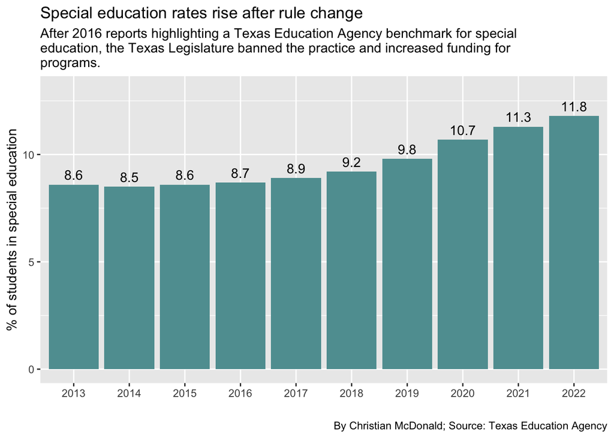

```r
yearly_percent |>
  ggplot(aes(x = year, y = sped_percent)) +
  geom_col(fill = "cadetblue") +
  geom_text(aes(label = sped_percent, vjust = -.5)) +
  ylim(0,13) +
  labs(
    title = "Special education rates rise after rule change",
    subtitle = str_wrap("After 2016 reports highlighting a Texas Education Agency benchmark for special education, the Texas Legislature banned the practice and increased funding for programs."),
    x = "", y = "% of students in special education",
    caption = "By Christian McDonald; Source: Texas Education Agency"
  )
```

### Plot local districts

Let’s look at some individual districts in the Austin area to make sure the trend tracks.

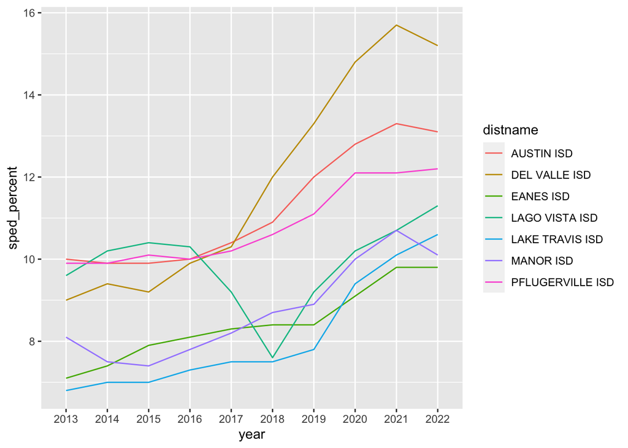

```r
sped |>
  filter(cntyname == "TRAVIS" & distname != "UNIVERSITY OF TEXAS AT AUSTIN H S") |>
  ggplot(aes(x = year, y = sped_percent, group = distname)) +
  geom_line(aes(color = distname))
```